# Análise Exploratória de Dados em Linguagem Python Para a Área de Varejo.

## Análise Exploratória de Dados em Linguagem Python Para a Área de Varejo

```python
import numpy as np
import pandas as pd
import matplotlib.pyplot as plt
import seaborn as sns
import datetime as dt
```

## Carregando os Dados

```python
url = 'https://raw.githubusercontent.com/jeferson-paz/Curso-de-Python-DSA/main/Cap13/dados/dataset.csv'
```

```python
df = pd.read_csv(url)
```

```python
print(df.head())
```

```
        ID_Pedido Data_Pedido ID_Cliente   Segmento           Pais  \
0  CA-2017-152156  08/11/2017   CG-12520   Consumer  United States
1  CA-2017-152156  08/11/2017   CG-12520   Consumer  United States
2  CA-2017-138688  12/06/2017   DV-13045  Corporate  United States
3  US-2016-108966  11/10/2016   SO-20335   Consumer  United States
4  US-2016-108966  11/10/2016   SO-20335   Consumer  United States

            Cidade      Estado       ID_Produto        Categoria SubCategoria  \
0        Henderson    Kentucky  FUR-BO-10001798        Furniture    Bookcases
1        Henderson    Kentucky  FUR-CH-10000454        Furniture       Chairs
2      Los Angeles  California  OFF-LA-10000240  Office Supplies       Labels
3  Fort Lauderdale     Florida  FUR-TA-10000577        Furniture       Tables
4  Fort Lauderdale     Florida  OFF-ST-10000760  Office Supplies      Storage

   Valor_Venda
0     261.9600
1     731.9400
2      14.6200
3     957.5775
4      22.3680
```

```python
df.shape
```

```
(9700, 11)
```

```python
df.head()
```

|  | ID_Pedido | Data_Pedido | ID_Cliente | Segmento | Pais | Cidade | Estado | ID_Produto | Categoria | SubCategoria | Valor_Venda |
| --- | --- | --- | --- | --- | --- | --- | --- | --- | --- | --- | --- |
| 0 | CA-2017-152156 | 08/11/2017 | CG-12520 | Consumer | United States | Henderson | Kentucky | FUR-BO-10001798 | Furniture | Bookcases | 261.9600 |
| 1 | CA-2017-152156 | 08/11/2017 | CG-12520 | Consumer | United States | Henderson | Kentucky | FUR-CH-10000454 | Furniture | Chairs | 731.9400 |
| 2 | CA-2017-138688 | 12/06/2017 | DV-13045 | Corporate | United States | Los Angeles | California | OFF-LA-10000240 | Office Supplies | Labels | 14.6200 |
| 3 | US-2016-108966 | 11/10/2016 | SO-20335 | Consumer | United States | Fort Lauderdale | Florida | FUR-TA-10000577 | Furniture | Tables | 957.5775 |
| 4 | US-2016-108966 | 11/10/2016 | SO-20335 | Consumer | United States | Fort Lauderdale | Florida | OFF-ST-10000760 | Office Supplies | Storage | 22.3680 |

```python
df.tail()
```

|  | ID_Pedido | Data_Pedido | ID_Cliente | Segmento | Pais | Cidade | Estado | ID_Produto | Categoria | SubCategoria | Valor_Venda |
| --- | --- | --- | --- | --- | --- | --- | --- | --- | --- | --- | --- |
| 9695 | CA-2018-154116 | 15/12/2018 | KM-16660 | Consumer | United States | Inglewood | California | OFF-PA-10004569 | Office Supplies | Paper | 22.830 |
| 9696 | CA-2018-154116 | 15/12/2018 | KM-16660 | Consumer | United States | Inglewood | California | OFF-AP-10000027 | Office Supplies | Appliances | 54.320 |
| 9697 | CA-2018-154116 | 15/12/2018 | KM-16660 | Consumer | United States | Inglewood | California | TEC-PH-10000675 | Technology | Phones | 196.776 |
| 9698 | CA-2017-105291 | 30/10/2017 | SP-20920 | Consumer | United States | San Luis Obispo | California | OFF-FA-10003059 | Office Supplies | Fasteners | 3.620 |
| 9699 | CA-2018-147032 | 31/07/2018 | LB-16795 | Home Office | United States | Wilmington | Delaware | OFF-PA-10003256 | Office Supplies | Paper | 11.540 |

## Análise Exploratória

```python
df.columns
```

```
Index(['ID_Pedido', 'Data_Pedido', 'ID_Cliente', 'Segmento', 'Pais', 'Cidade',
       'Estado', 'ID_Produto', 'Categoria', 'SubCategoria', 'Valor_Venda'],
      dtype='object')
```

```python
df.dtypes
```

```
ID_Pedido        object
Data_Pedido      object
ID_Cliente       object
Segmento         object
Pais             object
Cidade           object
Estado           object
ID_Produto       object
Categoria        object
SubCategoria     object
Valor_Venda     float64
dtype: object
```

```python
df['Valor_Venda'].describe()
```

```
count     9700.000000
mean       230.469892
std        627.504252
min          0.444000
25%         17.248000
50%         54.272000
75%        209.932500
max      22638.480000
Name: Valor_Venda, dtype: float64
```

```python
df[df.duplicated()]
```

|  | ID_Pedido | Data_Pedido | ID_Cliente | Segmento | Pais | Cidade | Estado | ID_Produto | Categoria | SubCategoria | Valor_Venda |
| --- | --- | --- | --- | --- | --- | --- | --- | --- | --- | --- | --- |

```python
df.isnull().sum()
```

```
ID_Pedido       0
Data_Pedido     0
ID_Cliente      0
Segmento        0
Pais            0
Cidade          0
Estado          0
ID_Produto      0
Categoria       0
SubCategoria    0
Valor_Venda     0
dtype: int64
```

```python
df.head()
```

|  | ID_Pedido | Data_Pedido | ID_Cliente | Segmento | Pais | Cidade | Estado | ID_Produto | Categoria | SubCategoria | Valor_Venda |
| --- | --- | --- | --- | --- | --- | --- | --- | --- | --- | --- | --- |
| 0 | CA-2017-152156 | 08/11/2017 | CG-12520 | Consumer | United States | Henderson | Kentucky | FUR-BO-10001798 | Furniture | Bookcases | 261.9600 |
| 1 | CA-2017-152156 | 08/11/2017 | CG-12520 | Consumer | United States | Henderson | Kentucky | FUR-CH-10000454 | Furniture | Chairs | 731.9400 |
| 2 | CA-2017-138688 | 12/06/2017 | DV-13045 | Corporate | United States | Los Angeles | California | OFF-LA-10000240 | Office Supplies | Labels | 14.6200 |
| 3 | US-2016-108966 | 11/10/2016 | SO-20335 | Consumer | United States | Fort Lauderdale | Florida | FUR-TA-10000577 | Furniture | Tables | 957.5775 |
| 4 | US-2016-108966 | 11/10/2016 | SO-20335 | Consumer | United States | Fort Lauderdale | Florida | OFF-ST-10000760 | Office Supplies | Storage | 22.3680 |

## Pergunta de Negócio 1:

### Qual Cidade com Maior Valor de Venda de Produtos da Categoria 'Office Supplies'?

```python
df_dsa_p1 = df[df['Categoria'] == 'Office Supplies']
```

```python
df_dsa_p1_total = df_dsa_p1.groupby('Cidade')['Valor_Venda'].sum()
```

```python
cidade_maior_venda = df_dsa_p1_total.idxmax()
print("Cidade com maior valor de venda para 'Office Supplies':", cidade_maior_venda)
```

```
Cidade com maior valor de venda para 'Office Supplies': New York City
```

```python
df_dsa_p1_total.sort_values(ascending = False)
```

```
Cidade
New York City    68362.814
Los Angeles      47098.100
San Francisco    41771.198
Seattle          34856.878
Philadelphia     29313.687
                   ...
Ormond Beach         2.808
Pensacola            2.214
Jupiter              2.064
Elyria               1.824
Abilene              1.392
Name: Valor_Venda, Length: 480, dtype: float64
```

## Pergunta de Negócio 2:

### Qual o Total de Vendas Por Data do Pedido?

Demonstre o resultado através de um gráfico de barras.

```python
df = df.groupby('Data_Pedido')['Valor_Venda'].sum()
```

```python
df.head()
```

```
Data_Pedido
01/01/2018    1481.8280
01/02/2015     468.9000
01/02/2017     161.9700
01/03/2015    2203.1510
01/03/2016    1642.1744
Name: Valor_Venda, dtype: float64
```

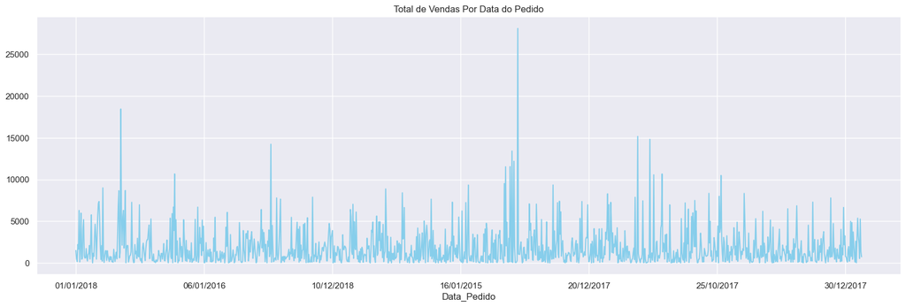

```python
plt.figure(figsize = (20, 6))
df.plot(x = 'Data_Pedido', y = 'Valor_Venda', color = 'skyblue')
plt.title('Total de Vendas Por Data do Pedido')
plt.show()
```

## Pergunta de Negócio 3:

### Qual o Total de Vendas por Estado?

Demonstre o resultado através de um gráfico de barras.

```python
url = 'https://raw.githubusercontent.com/jeferson-paz/Curso-de-Python-DSA/main/Cap13/dados/dataset.csv'
```

```python
df = pd.read_csv(url)
```

```python
print(df.head())
```

```
        ID_Pedido Data_Pedido ID_Cliente   Segmento           Pais  \
0  CA-2017-152156  08/11/2017   CG-12520   Consumer  United States
1  CA-2017-152156  08/11/2017   CG-12520   Consumer  United States
2  CA-2017-138688  12/06/2017   DV-13045  Corporate  United States
3  US-2016-108966  11/10/2016   SO-20335   Consumer  United States
4  US-2016-108966  11/10/2016   SO-20335   Consumer  United States

            Cidade      Estado       ID_Produto        Categoria SubCategoria  \
0        Henderson    Kentucky  FUR-BO-10001798        Furniture    Bookcases
1        Henderson    Kentucky  FUR-CH-10000454        Furniture       Chairs
2      Los Angeles  California  OFF-LA-10000240  Office Supplies       Labels
3  Fort Lauderdale     Florida  FUR-TA-10000577        Furniture       Tables
4  Fort Lauderdale     Florida  OFF-ST-10000760  Office Supplies      Storage

   Valor_Venda
0     261.9600
1     731.9400
2      14.6200
3     957.5775
4      22.3680
```

```python
df = df.groupby('Estado')['Valor_Venda'].sum().reset_index()
```

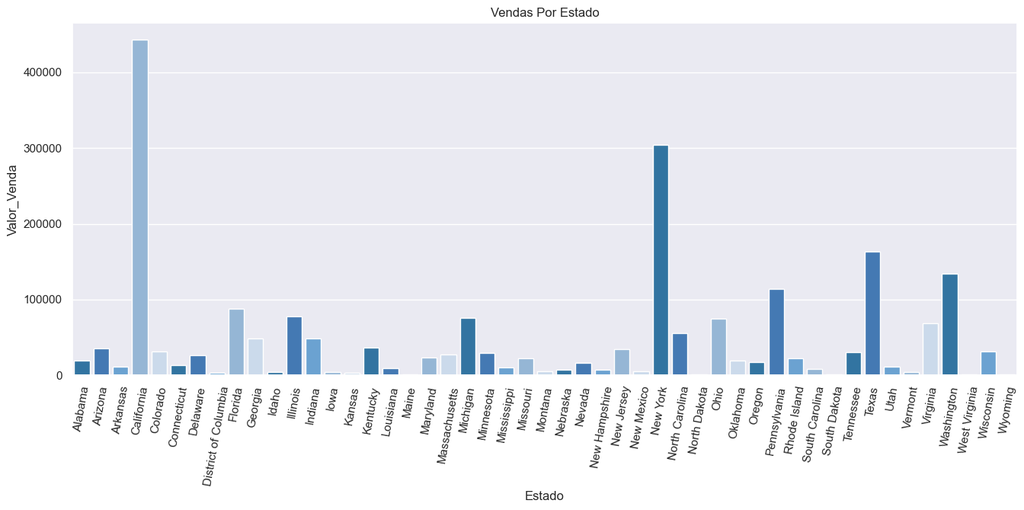

```python
plt.figure(figsize = (16, 6))

# Defina uma paleta personalizada
custom_palette = sns.color_palette(["#1f77b4", "#3178c6", "#5aa3e2", "#8ab7e0", "#c6d9f0"])

sns.barplot(data = df,
            y = 'Valor_Venda',
            x = 'Estado',
            palette=custom_palette).set(title = 'Vendas Por Estado')

plt.xticks(rotation = 80)
plt.show()
```

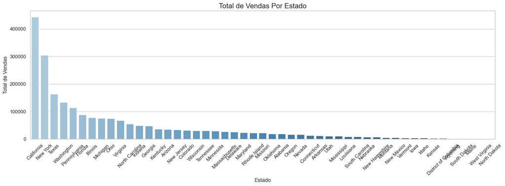

```python
df_dsa_p3 = df.groupby('Estado')['Valor_Venda'].sum().reset_index()

df_dsa_p3 = df_dsa_p3.sort_values(by='Valor_Venda', ascending=False)

sns.set_theme(style="whitegrid")
plt.figure(figsize=(16, 6))

ax = sns.barplot(x='Estado', y='Valor_Venda', data=df_dsa_p3, palette='Blues_d')

plt.xlabel('Estado', fontsize=12)
plt.ylabel('Total de Vendas', fontsize=12)
plt.title('Total de Vendas Por Estado', fontsize=16)
plt.xticks(rotation=45)

plt.tight_layout()

plt.show()
```

## Pergunta de Negócio 4:

### Quais São as 10 Cidades com Maior Total de Vendas?

Demonstre o resultado através de um gráfico de barras.

```python
url = 'https://raw.githubusercontent.com/jeferson-paz/Curso-de-Python-DSA/main/Cap13/dados/dataset.csv'
```

```python
df = pd.read_csv(url)
```

```python
vendas_por_cidade = df.groupby('Cidade')['Valor_Venda'].sum().reset_index()
top_10_cidades = vendas_por_cidade.sort_values(by='Valor_Venda', ascending=False).head(10)
```

```python
top_10_cidades.head(10)
```

|  | Cidade | Valor_Venda |
| --- | --- | --- |
| 327 | New York City | 251749.2190 |
| 265 | Los Angeles | 171654.6330 |
| 450 | Seattle | 114725.4780 |
| 436 | San Francisco | 107489.9520 |
| 372 | Philadelphia | 107197.8030 |
| 207 | Houston | 61590.1868 |
| 435 | San Diego | 47458.3790 |
| 80 | Chicago | 46974.3430 |
| 216 | Jacksonville | 44713.1830 |
| 123 | Detroit | 42446.9440 |

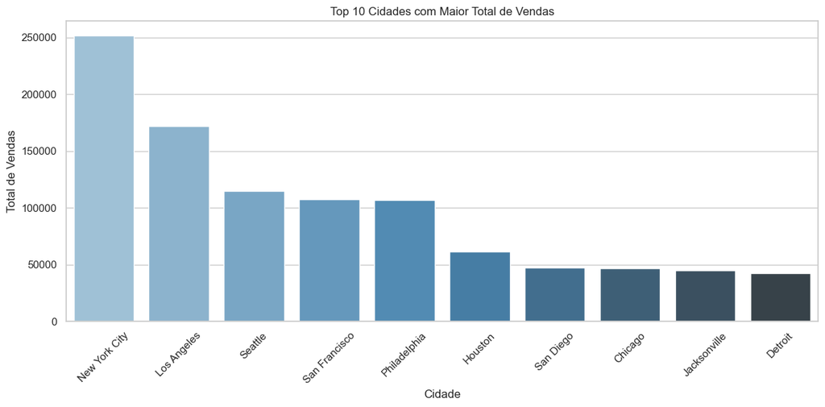

```python
sns.set(style="whitegrid")
plt.figure(figsize=(12, 6))
sns.barplot(x='Cidade', y='Valor_Venda', data=top_10_cidades, palette='Blues_d')
plt.xlabel('Cidade')
plt.ylabel('Total de Vendas')
plt.title('Top 10 Cidades com Maior Total de Vendas')
plt.xticks(rotation=45)
plt.tight_layout()
plt.show()
```

## Pergunta de Negócio 5:

### Qual Segmento Teve o Maior Total de Vendas?

Demonstre o resultado através de um gráfico de pizza.

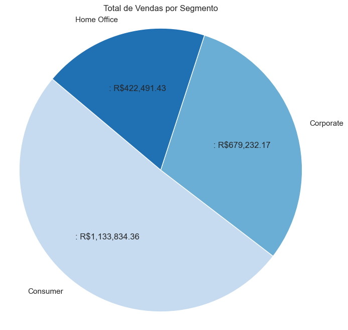

```python
vendas_por_segmento = df.groupby('Segmento')['Valor_Venda'].sum().reset_index()


def formato_pie(valores, labels):
    return [f'{label}: R${valor:,.2f}' for valor, label in zip(valores, labels)]

cores = sns.color_palette("Blues", len(vendas_por_segmento))

plt.figure(figsize=(8, 8))
plt.pie(vendas_por_segmento['Valor_Venda'],
        labels=vendas_por_segmento['Segmento'],
        colors=cores,
        autopct=lambda pct: formato_pie([pct * sum(vendas_por_segmento['Valor_Venda']) / 100], [''])[0],
        startangle=140)
plt.title('Total de Vendas por Segmento')
plt.axis('equal')
plt.show()
```

## Pergunta de Negócio 6:

### Qual o Total de Vendas Por Segmento e Por Ano?

```python
df.head()
```

|  | ID_Pedido | Data_Pedido | ID_Cliente | Segmento | Pais | Cidade | Estado | ID_Produto | Categoria | SubCategoria | Valor_Venda |
| --- | --- | --- | --- | --- | --- | --- | --- | --- | --- | --- | --- |
| 0 | CA-2017-152156 | 08/11/2017 | CG-12520 | Consumer | United States | Henderson | Kentucky | FUR-BO-10001798 | Furniture | Bookcases | 261.9600 |
| 1 | CA-2017-152156 | 08/11/2017 | CG-12520 | Consumer | United States | Henderson | Kentucky | FUR-CH-10000454 | Furniture | Chairs | 731.9400 |
| 2 | CA-2017-138688 | 12/06/2017 | DV-13045 | Corporate | United States | Los Angeles | California | OFF-LA-10000240 | Office Supplies | Labels | 14.6200 |
| 3 | US-2016-108966 | 11/10/2016 | SO-20335 | Consumer | United States | Fort Lauderdale | Florida | FUR-TA-10000577 | Furniture | Tables | 957.5775 |
| 4 | US-2016-108966 | 11/10/2016 | SO-20335 | Consumer | United States | Fort Lauderdale | Florida | OFF-ST-10000760 | Office Supplies | Storage | 22.3680 |

```python
df['Data_Pedido'] = pd.to_datetime(df['Data_Pedido'], dayfirst = True)
```

```python
df.dtypes
```

```
ID_Pedido               object
Data_Pedido     datetime64[ns]
ID_Cliente              object
Segmento                object
Pais                    object
Cidade                  object
Estado                  object
ID_Produto              object
Categoria               object
SubCategoria            object
Valor_Venda            float64
dtype: object
```

```python
df['Ano'] = df['Data_Pedido'].dt.year
```

```python
df.head()
```

|  | ID_Pedido | Data_Pedido | ID_Cliente | Segmento | Pais | Cidade | Estado | ID_Produto | Categoria | SubCategoria | Valor_Venda | Ano |
| --- | --- | --- | --- | --- | --- | --- | --- | --- | --- | --- | --- | --- |
| 0 | CA-2017-152156 | 2017-11-08 | CG-12520 | Consumer | United States | Henderson | Kentucky | FUR-BO-10001798 | Furniture | Bookcases | 261.9600 | 2017 |
| 1 | CA-2017-152156 | 2017-11-08 | CG-12520 | Consumer | United States | Henderson | Kentucky | FUR-CH-10000454 | Furniture | Chairs | 731.9400 | 2017 |
| 2 | CA-2017-138688 | 2017-06-12 | DV-13045 | Corporate | United States | Los Angeles | California | OFF-LA-10000240 | Office Supplies | Labels | 14.6200 | 2017 |
| 3 | US-2016-108966 | 2016-10-11 | SO-20335 | Consumer | United States | Fort Lauderdale | Florida | FUR-TA-10000577 | Furniture | Tables | 957.5775 | 2016 |
| 4 | US-2016-108966 | 2016-10-11 | SO-20335 | Consumer | United States | Fort Lauderdale | Florida | OFF-ST-10000760 | Office Supplies | Storage | 22.3680 | 2016 |

```python
df_dsa_p6 = df.groupby(['Ano', 'Segmento'])['Valor_Venda'].sum()
```

```python
df_dsa_p6
```

```
Ano   Segmento
2015  Consumer       256719.9166
      Corporate      125819.5957
      Home Office     88229.0878
2016  Consumer       265295.2593
      Corporate      114643.1229
      Home Office     74134.1332
2017  Consumer       288459.5572
      Corporate      203266.7398
      Home Office    103639.6270
2018  Consumer       323359.6019
      Corporate      235502.7284
      Home Office    156488.5849
Name: Valor_Venda, dtype: float64
```

## Pergunta de Negócio 7:

Os gestores da empresa estão considerando conceder diferentes faixas de descontos e gostariam de fazer uma simulação com base na regra abaixo:

- Se o Valor_Venda for maior que 1000 recebe 15% de desconto.
- Se o Valor_Venda for menor que 1000 recebe 10% de desconto.

### Quantas Vendas Receberiam 15% de Desconto?

```python
df['Desconto'] = np.where(df['Valor_Venda'] > 1000, 0.15, 0.10)
```

```python
df.head()
```

|  | ID_Pedido | Data_Pedido | ID_Cliente | Segmento | Pais | Cidade | Estado | ID_Produto | Categoria | SubCategoria | Valor_Venda | Ano | Desconto |
| --- | --- | --- | --- | --- | --- | --- | --- | --- | --- | --- | --- | --- | --- |
| 0 | CA-2017-152156 | 2017-11-08 | CG-12520 | Consumer | United States | Henderson | Kentucky | FUR-BO-10001798 | Furniture | Bookcases | 261.9600 | 2017 | 0.1 |
| 1 | CA-2017-152156 | 2017-11-08 | CG-12520 | Consumer | United States | Henderson | Kentucky | FUR-CH-10000454 | Furniture | Chairs | 731.9400 | 2017 | 0.1 |
| 2 | CA-2017-138688 | 2017-06-12 | DV-13045 | Corporate | United States | Los Angeles | California | OFF-LA-10000240 | Office Supplies | Labels | 14.6200 | 2017 | 0.1 |
| 3 | US-2016-108966 | 2016-10-11 | SO-20335 | Consumer | United States | Fort Lauderdale | Florida | FUR-TA-10000577 | Furniture | Tables | 957.5775 | 2016 | 0.1 |
| 4 | US-2016-108966 | 2016-10-11 | SO-20335 | Consumer | United States | Fort Lauderdale | Florida | OFF-ST-10000760 | Office Supplies | Storage | 22.3680 | 2016 | 0.1 |

```python
df['Desconto'].value_counts()
```

```
Desconto
0.10    9243
0.15     457
Name: count, dtype: int64
```

```python
print('No Total 457 Vendas Receberiam Desconto de 15%.')
```

```
No Total 457 Vendas Receberiam Desconto de 15%.
```

## Pergunta de Negócio 8:

### Considere Que a Empresa Decida Conceder o Desconto de 15% do Item Anterior. Qual Seria a Média do Valor de Venda Antes e Depois do Desconto?

```python
df['Valor_Venda_Desconto'] = df['Valor_Venda'] - (df['Valor_Venda'] * df['Desconto'])
```

```python
df.head()
```

|  | ID_Pedido | Data_Pedido | ID_Cliente | Segmento | Pais | Cidade | Estado | ID_Produto | Categoria | SubCategoria | Valor_Venda | Ano | Desconto | Valor_Venda_Desconto |
| --- | --- | --- | --- | --- | --- | --- | --- | --- | --- | --- | --- | --- | --- | --- |
| 0 | CA-2017-152156 | 2017-11-08 | CG-12520 | Consumer | United States | Henderson | Kentucky | FUR-BO-10001798 | Furniture | Bookcases | 261.9600 | 2017 | 0.1 | 235.76400 |
| 1 | CA-2017-152156 | 2017-11-08 | CG-12520 | Consumer | United States | Henderson | Kentucky | FUR-CH-10000454 | Furniture | Chairs | 731.9400 | 2017 | 0.1 | 658.74600 |
| 2 | CA-2017-138688 | 2017-06-12 | DV-13045 | Corporate | United States | Los Angeles | California | OFF-LA-10000240 | Office Supplies | Labels | 14.6200 | 2017 | 0.1 | 13.15800 |
| 3 | US-2016-108966 | 2016-10-11 | SO-20335 | Consumer | United States | Fort Lauderdale | Florida | FUR-TA-10000577 | Furniture | Tables | 957.5775 | 2016 | 0.1 | 861.81975 |
| 4 | US-2016-108966 | 2016-10-11 | SO-20335 | Consumer | United States | Fort Lauderdale | Florida | OFF-ST-10000760 | Office Supplies | Storage | 22.3680 | 2016 | 0.1 | 20.13120 |

```python
df_dsa_p8_vendas_antes_desconto = df.loc[df['Desconto'] == 0.15, 'Valor_Venda']
```

```python
df_dsa_p8_vendas_depois_desconto = df.loc[df['Desconto'] == 0.15, 'Valor_Venda_Desconto']
```

```python
media_vendas_antes_desconto = df_dsa_p8_vendas_antes_desconto.mean()
```

```python
media_vendas_depois_desconto = df_dsa_p8_vendas_depois_desconto.mean()
```

```python
print("Média das vendas antes do desconto de 15%:", round(media_vendas_antes_desconto, 2))
```

```
Média das vendas antes do desconto de 15%: 2116.81
```

```python
print("Média das vendas depois do desconto de 15%:", round(media_vendas_depois_desconto, 2))
```

```
Média das vendas depois do desconto de 15%: 1799.29
```

## Pergunta de Negócio 9:

### Qual o Média de Vendas Por Segmento, Por Ano e Por Mês?

Demonstre o resultado através de gráfico de linha.

```python
df['Mes'] = df['Data_Pedido'].dt.month
```

```python
df.head()
```

|  | ID_Pedido | Data_Pedido | ID_Cliente | Segmento | Pais | Cidade | Estado | ID_Produto | Categoria | SubCategoria | Valor_Venda | Ano | Desconto | Valor_Venda_Desconto | Mes |
| --- | --- | --- | --- | --- | --- | --- | --- | --- | --- | --- | --- | --- | --- | --- | --- |
| 0 | CA-2017-152156 | 2017-11-08 | CG-12520 | Consumer | United States | Henderson | Kentucky | FUR-BO-10001798 | Furniture | Bookcases | 261.9600 | 2017 | 0.1 | 235.76400 | 11 |
| 1 | CA-2017-152156 | 2017-11-08 | CG-12520 | Consumer | United States | Henderson | Kentucky | FUR-CH-10000454 | Furniture | Chairs | 731.9400 | 2017 | 0.1 | 658.74600 | 11 |
| 2 | CA-2017-138688 | 2017-06-12 | DV-13045 | Corporate | United States | Los Angeles | California | OFF-LA-10000240 | Office Supplies | Labels | 14.6200 | 2017 | 0.1 | 13.15800 | 6 |
| 3 | US-2016-108966 | 2016-10-11 | SO-20335 | Consumer | United States | Fort Lauderdale | Florida | FUR-TA-10000577 | Furniture | Tables | 957.5775 | 2016 | 0.1 | 861.81975 | 10 |
| 4 | US-2016-108966 | 2016-10-11 | SO-20335 | Consumer | United States | Fort Lauderdale | Florida | OFF-ST-10000760 | Office Supplies | Storage | 22.3680 | 2016 | 0.1 | 20.13120 | 10 |

```python
df_dsa_p9 = df.groupby(['Ano', 'Mes', 'Segmento'])['Valor_Venda'].agg([np.sum, np.mean, np.median])
```

```python
df_dsa_p9
```

| Ano | Mes | Segmento | sum | mean | median |
| --- | --- | --- | --- | --- | --- |
| 2015 | 1 | Consumer | 6896.6290 | 146.736787 | 36.440 |
|  |  | Corporate | 1701.5280 | 130.886769 | 51.940 |
|  |  | Home Office | 5607.5500 | 329.855882 | 62.820 |
|  | 2 | Consumer | 3167.8540 | 117.327926 | 22.776 |
|  |  | Corporate | 623.1180 | 69.235333 | 62.310 |
| ... | ... | ... | ... | ... | ... |
| 2018 | 11 | Corporate | 44357.9862 | 341.215278 | 79.530 |
|  |  | Home Office | 24009.3840 | 247.519423 | 56.560 |
|  | 12 | Consumer | 48107.4558 | 183.616244 | 52.533 |
|  |  | Corporate | 20524.4320 | 153.167403 | 46.460 |
|  |  | Home Office | 13022.3910 | 224.523983 | 49.260 |

144 rows × 3 columns

```python
anos = df_dsa_p9.index.get_level_values(0)
meses = df_dsa_p9.index.get_level_values(1)
segmentos = df_dsa_p9.index.get_level_values(2)
```

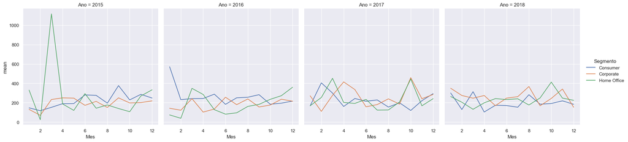

```python
plt.figure(figsize = (12, 6))
sns.set()
fig1 = sns.relplot(kind = 'line',
                data = df_dsa_p9,
                y = 'mean',
                x = meses,
                hue = segmentos,
                col = anos,
                col_wrap = 4)
plt.show()
```

## Pergunta de Negócio 10:

### Qual o Total de Vendas Por Categoria e SubCategoria, Considerando Somente as Top 12 SubCategorias?

Demonstre tudo através de um único gráfico.

```python
df.head()
```

|  | ID_Pedido | Data_Pedido | ID_Cliente | Segmento | Pais | Cidade | Estado | ID_Produto | Categoria | SubCategoria | Valor_Venda | Ano | Desconto | Valor_Venda_Desconto | Mes |
| --- | --- | --- | --- | --- | --- | --- | --- | --- | --- | --- | --- | --- | --- | --- | --- |
| 0 | CA-2017-152156 | 2017-11-08 | CG-12520 | Consumer | United States | Henderson | Kentucky | FUR-BO-10001798 | Furniture | Bookcases | 261.9600 | 2017 | 0.1 | 235.76400 | 11 |
| 1 | CA-2017-152156 | 2017-11-08 | CG-12520 | Consumer | United States | Henderson | Kentucky | FUR-CH-10000454 | Furniture | Chairs | 731.9400 | 2017 | 0.1 | 658.74600 | 11 |
| 2 | CA-2017-138688 | 2017-06-12 | DV-13045 | Corporate | United States | Los Angeles | California | OFF-LA-10000240 | Office Supplies | Labels | 14.6200 | 2017 | 0.1 | 13.15800 | 6 |
| 3 | US-2016-108966 | 2016-10-11 | SO-20335 | Consumer | United States | Fort Lauderdale | Florida | FUR-TA-10000577 | Furniture | Tables | 957.5775 | 2016 | 0.1 | 861.81975 | 10 |
| 4 | US-2016-108966 | 2016-10-11 | SO-20335 | Consumer | United States | Fort Lauderdale | Florida | OFF-ST-10000760 | Office Supplies | Storage | 22.3680 | 2016 | 0.1 | 20.13120 | 10 |

```python
df_dsa_p10 = df.groupby(['Categoria',
                            'SubCategoria']).sum(numeric_only = True).sort_values('Valor_Venda',
                                                                                ascending = False).head(12)
```

```python
df_dsa_p10 = df_dsa_p10[['Valor_Venda']].astype(int).sort_values(by = 'Categoria').reset_index()
```

```python
df_dsa_p10
```

|  | Categoria | SubCategoria | Valor_Venda |
| --- | --- | --- | --- |
| 0 | Furniture | Chairs | 317919 |
| 1 | Furniture | Tables | 202083 |
| 2 | Furniture | Bookcases | 108045 |
| 3 | Furniture | Furnishings | 88862 |
| 4 | Office Supplies | Storage | 216188 |
| 5 | Office Supplies | Binders | 194723 |
| 6 | Office Supplies | Appliances | 104061 |
| 7 | Office Supplies | Paper | 76312 |
| 8 | Technology | Phones | 325271 |
| 9 | Technology | Machines | 189238 |
| 10 | Technology | Accessories | 162791 |
| 11 | Technology | Copiers | 146248 |

```python
df_dsa_p10_cat = df_dsa_p10.groupby('Categoria').sum(numeric_only = True).reset_index()
```

```python
df_dsa_p10_cat
```

|  | Categoria | Valor_Venda |
| --- | --- | --- |
| 0 | Furniture | 716909 |
| 1 | Office Supplies | 591284 |
| 2 | Technology | 823548 |

```python
cores_categorias = ['#0031d8',
                    '#0091d8',
                    '#00d1d8']
```

```python
cores_subcategorias = ['#a0b4d8',
                       '#9fb1d8',
                       '#8ea1d8',
                       '#7d8fd8',
                       '#6a8dd8',
                       '#5681d8',
                       '#4284d8',
                       '#2b6fd8',
                       '#1e6bd8',
                       '#185cd8',
                       '#0f4bd8',
                       '#003ad8']
```

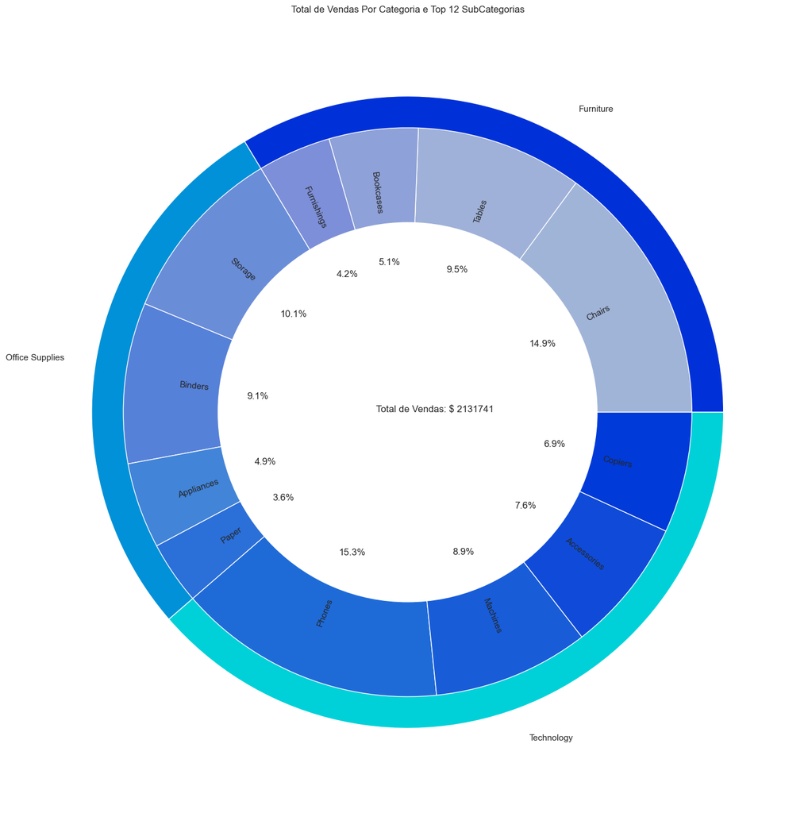

```python
fig, ax = plt.subplots(figsize=(20, 18))


p1 = ax.pie(df_dsa_p10_cat['Valor_Venda'],
            radius=1,
            labels=df_dsa_p10_cat['Categoria'],
            wedgeprops=dict(edgecolor='white'),
            colors=cores_categorias)

p2 = ax.pie(df_dsa_p10['Valor_Venda'],
            radius=0.9,
            labels=df_dsa_p10['SubCategoria'],
            autopct='%1.1f%%',
            colors=cores_subcategorias,
            labeldistance=0.7,
            wedgeprops=dict(edgecolor='white'),
            pctdistance=0.53,
            rotatelabels=True)

centre_circle = plt.Circle((0, 0), 0.6, fc='white')
fig.gca().add_artist(centre_circle)

plt.annotate(text='Total de Vendas: $ ' + str(int(sum(df_dsa_p10['Valor_Venda']))), xy=(-0.1, 0))

plt.title('Total de Vendas Por Categoria e Top 12 SubCategorias')

plt.show()
```

## Resumo da Análise

Nesta análise exploratória de dados, focamos em diversas perguntas de negócio cruciais para a área de varejo, utilizando ferramentas avançadas de visualização em Python. A seguir, apresentamos uma visão geral dos principais resultados e insights obtidos:

### Total de Vendas Por Categoria e Subcategoria (Top 12 Subcategorias)

A análise revelou o total de vendas agrupado por categoria e subcategoria, considerando as 12 principais subcategorias. O gráfico gerado ilustra claramente as diferenças de desempenho entre as subcategorias e categorias, permitindo identificar quais subcategorias são mais relevantes em termos de vendas.

### Média de Vendas Por Segmento, Ano e Mês

Utilizando gráficos de linha, examinamos a média de vendas por segmento ao longo dos anos e meses. Esta visualização fornece uma compreensão detalhada das variações sazonais e tendências de vendas ao longo do tempo, ajudando na tomada de decisões estratégicas.

### Simulação de Descontos

Com base nas regras de desconto definidas (15% para vendas acima de 1000 e 10% para vendas abaixo de 1000), foi realizada uma simulação para identificar o número de vendas que receberiam 15% de desconto. Este insight é valioso para a formulação de estratégias promocionais e políticas de descontos.

### Segmento com Maior Total de Vendas

Um gráfico de pizza foi criado para destacar o segmento com o maior total de vendas. Esta visualização permite identificar qual segmento é o mais lucrativo e estratégico para a empresa.

### Top 10 Cidades com Maior Total de Vendas

Através de um gráfico de barras, foram destacadas as 10 cidades com o maior total de vendas. Este gráfico fornece informações importantes sobre a distribuição regional das vendas e pode auxiliar na alocação de recursos e estratégias de marketing localizadas.

Esta análise proporciona uma visão abrangente das métricas de vendas e ajuda a identificar áreas de oportunidade e otimização. As visualizações criadas oferecem uma maneira eficaz de comunicar insights complexos de forma clara e impactante, apoiando a tomada de decisões estratégicas e a melhoria contínua dos processos de negócios.